# Estimation of seatrout weight in Karup Å

Lars Relund Nielsen

19/3/2020

We consider catch records from Karup Å in years 2003-2020 with both weight and length numbers. A total of 15669 observations.

## Model 1: log(Weight) ~ log(Length)

Let us first try a simple model with [weight as function of length](https://en.wikipedia.org/wiki/Standard_weight_in_fish):

```
#>
#> Call:
#> lm(formula = log(Weight) ~ log(Length), data = dat)
#>
#> Residuals:
#>      Min       1Q   Median       3Q      Max
#> -1.13766 -0.05952  0.02138  0.07404  0.72500
#>
#> Coefficients:
#>               Estimate Std. Error t value Pr(>|t|)
#> (Intercept) -11.546816   0.021308  -541.9   <2e-16 ***
#> log(Length)   3.043549   0.005214   583.7   <2e-16 ***
#> ---
#> Signif. codes:  0 '***' 0.001 '**' 0.01 '*' 0.05 '.' 0.1 ' ' 1
#>
#> Residual standard error: 0.1307 on 15667 degrees of freedom
#> Multiple R-squared:  0.956,  Adjusted R-squared:  0.956
#> F-statistic: 3.407e+05 on 1 and 15667 DF,  p-value: < 2.2e-16
```

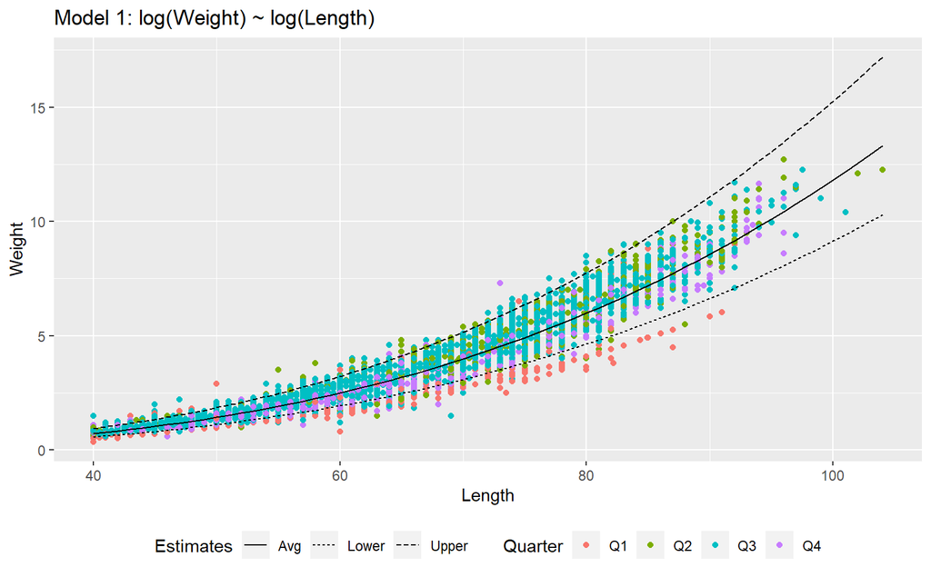

The estimated formula for weight ($w$) of a seatrout as a funtion of length ($l$) becomes:

$$v = 9.67\times 10^{-6} \cdot l^{3.04}$$

Estimates with 95% confidence intervals are:

| Length | Avg | Lower | Upper | Fulton |
| --- | --- | --- | --- | --- |
| 40 | 0.726489067039282 | 0.562232281026465 | 0.938733655712599 | 1.13513916724888 |
| 41 | 0.783191002752698 | 0.606116415624635 | 1.01199725165115 | 1.13636047467782 |
| 42 | 0.842790723775342 | 0.652243292507228 | 1.08900499589866 | 1.13755361701671 |
| 43 | 0.905362024274354 | 0.700670014269267 | 1.16985225327932 | 1.13871989167539 |
| 44 | 0.970978774985828 | 0.751453741960643 | 1.25463448889494 | 1.13986050782521 |
| 45 | 1.03971492151021 | 0.804651693771229 | 1.34344726591518 | 1.14097659424988 |
| 46 | 1.11164448268354 | 0.860321143774798 | 1.43638624346564 | 1.14206920634045 |
| 47 | 1.18684154901963 | 0.918519420727887 | 1.53354717460744 | 1.14313933234412 |
| 48 | 1.26538028121854 | 0.979303906920032 | 1.63502590440238 | 1.14418789896063 |
| 49 | 1.34733490873714 | 1.04273203707212 | 1.74091836805832 | 1.14521577636626 |

[output cut: 55 more lines]

Note that the condition factor for average weight value is quite constanct ([1.14,1.18]) and increasing with lenght. Moreover, the weights in the plot of the first quarter (Q1) seem to be lower. This holds with the biology of the trout. In March the may still be kelts in the river.

## Model 2: lm(log(Weight) ~ Month*log(Length)

Let us have a closer look at the data:

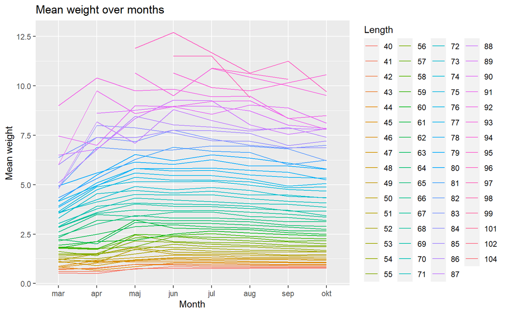

For medium lengths, weight goes up, peak and goes down again as expected. In March/April we still have kelts in the river and then fresh fish arrives (best condition/weight) which loose weight at they stay in the river. Note for small lengths (up to 50 cm) the difference is small; because, small fish may have other reasons than spawning for staying in the river (e.g. feeding or bad conditions in the fjord).

We fit a model taking month into account:

```
#>
#> Call:
#> lm(formula = log(Weight) ~ MonthM2 * log(Length), data = dat)
#>
#> Residuals:
#>      Min       1Q   Median       3Q      Max
#> -0.95775 -0.06405  0.00329  0.06028  0.94271
#>
#> Coefficients:
#>                         Estimate Std. Error  t value Pr(>|t|)
#> (Intercept)           -11.722727   0.032213 -363.917  < 2e-16 ***
#> MonthM2.L               0.463843   0.090869    5.105 3.35e-07 ***
#> MonthM2.Q               0.039648   0.067566    0.587 0.557340
#> MonthM2.C              -0.494375   0.095122   -5.197 2.05e-07 ***
#> MonthM2^4               0.974492   0.098418    9.902  < 2e-16 ***
#> MonthM2^5              -1.027819   0.104822   -9.805  < 2e-16 ***
#> MonthM2^6               0.514382   0.103211    4.984 6.30e-07 ***
#> MonthM2^7              -0.165919   0.070085   -2.367 0.017926 *
#> log(Length)             3.079040   0.007686  400.597  < 2e-16 ***
#> MonthM2.L:log(Length)  -0.076179   0.021804   -3.494 0.000477 ***
#> MonthM2.Q:log(Length)  -0.066897   0.016304   -4.103 4.10e-05 ***
#> MonthM2.C:log(Length)   0.142068   0.022653    6.272 3.67e-10 ***
#> MonthM2^4:log(Length)  -0.233056   0.023569   -9.888  < 2e-16 ***
#> MonthM2^5:log(Length)   0.239993   0.024969    9.612  < 2e-16 ***
#> MonthM2^6:log(Length)  -0.115320   0.024424   -4.722 2.36e-06 ***
#> MonthM2^7:log(Length)   0.035452   0.016687    2.125 0.033639 *
#> ---
#> Signif. codes:  0 '***' 0.001 '**' 0.01 '*' 0.05 '.' 0.1 ' ' 1
#>
#> Residual standard error: 0.1093 on 15653 degrees of freedom
#> Multiple R-squared:  0.9693, Adjusted R-squared:  0.9693
#> F-statistic: 3.296e+04 on 15 and 15653 DF,  p-value: < 2.2e-16
```

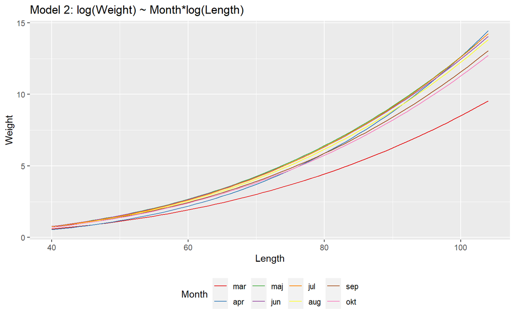

As expected mean weight decrease with the days the trout has been in the river (seems that April is the first month). We compare the two models:

```
#> Analysis of Variance Table
#>
#> Model 1: log(Weight) ~ log(Length)
#> Model 2: log(Weight) ~ MonthM2 * log(Length)
#>   Res.Df    RSS Df Sum of Sq      F    Pr(>F)
#> 1  15667 267.80
#> 2  15653 186.94 14    80.858 483.59 < 2.2e-16 ***
#> ---
#> Signif. codes:  0 '***' 0.001 '**' 0.01 '*' 0.05 '.' 0.1 ' ' 1
```

Model 2 provides a better fit. Note that the model here consider `Month` as ordinal data.

## Model 3: log(Weight) ~ factor(Month, ordered = F)*log(Length)

We try to fit a model where `Month` is a non-ordered factor.

```
#>
#> Call:
#> lm(formula = log(Weight) ~ MonthM3 * log(Length), data = dat)
#>
#> Residuals:
#>      Min       1Q   Median       3Q      Max
#> -0.95775 -0.06405  0.00329  0.06028  0.94271
#>
#> Coefficients:
#>                         Estimate Std. Error  t value Pr(>|t|)
#> (Intercept)            -11.27554    0.07765 -145.219  < 2e-16 ***
#> MonthM3apr              -1.96957    0.18209  -10.817  < 2e-16 ***
#> MonthM3maj              -0.17621    0.17001   -1.036  0.30001
#> MonthM3jun              -0.16369    0.09359   -1.749  0.08032 .
#> MonthM3jul              -0.37110    0.08442   -4.396 1.11e-05 ***
#> MonthM3aug              -0.40224    0.08617   -4.668 3.07e-06 ***
#> MonthM3sep              -0.25610    0.09260   -2.766  0.00569 **
#> MonthM3okt              -0.23854    0.09292   -2.567  0.01026 *
#> log(Length)              2.91347    0.01895  153.763  < 2e-16 ***
#> MonthM3apr:log(Length)   0.51343    0.04362   11.771  < 2e-16 ***
#> MonthM3maj:log(Length)   0.12418    0.04023    3.086  0.00203 **
#> MonthM3jun:log(Length)   0.11861    0.02280    5.202 2.00e-07 ***
#> MonthM3jul:log(Length)   0.16610    0.02064    8.048 9.05e-16 ***
#> MonthM3aug:log(Length)   0.16652    0.02106    7.905 2.85e-15 ***
#> MonthM3sep:log(Length)   0.12252    0.02259    5.423 5.94e-08 ***
#> MonthM3okt:log(Length)   0.11323    0.02266    4.996 5.90e-07 ***
#> ---
#> Signif. codes:  0 '***' 0.001 '**' 0.01 '*' 0.05 '.' 0.1 ' ' 1
#>
#> Residual standard error: 0.1093 on 15653 degrees of freedom
#> Multiple R-squared:  0.9693, Adjusted R-squared:  0.9693
#> F-statistic: 3.296e+04 on 15 and 15653 DF,  p-value: < 2.2e-16
```

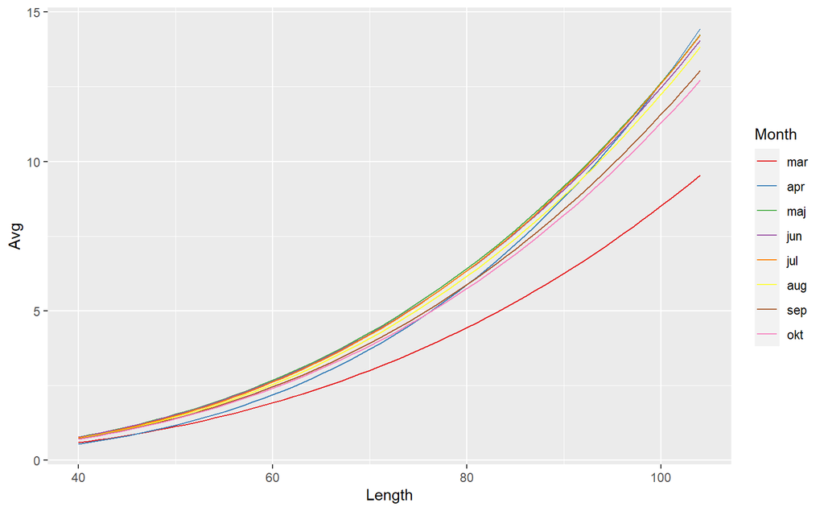

Since the degrees of freedom is the same we cannot use `anova`. Let us try to plot the two models:

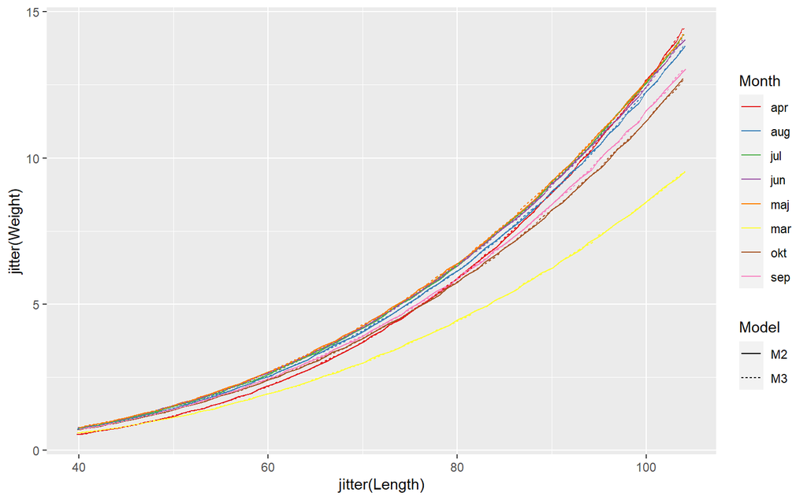

Its the same model, just formulated differently.

## Model 4: log(Weight) ~ MonthM*log(Length)

We may reorder the months so April is the first and then use `Month` as a numeric variable:

```
#>
#> Call:
#> lm(formula = log(Weight) ~ MonthM4 * log(Length), data = dat)
#>
#> Residuals:
#>      Min       1Q   Median       3Q      Max
#> -0.94140 -0.06269  0.00775  0.06919  0.89767
#>
#> Coefficients:
#>                       Estimate Std. Error  t value Pr(>|t|)
#> (Intercept)         -1.152e+01  4.824e-02 -238.808  < 2e-16 ***
#> MonthM4             -6.291e-04  8.826e-03   -0.071 0.943184
#> log(Length)          3.076e+00  1.173e-02  262.216  < 2e-16 ***
#> MonthM4:log(Length) -7.170e-03  2.145e-03   -3.342 0.000834 ***
#> ---
#> Signif. codes:  0 '***' 0.001 '**' 0.01 '*' 0.05 '.' 0.1 ' ' 1
#>
#> Residual standard error: 0.1144 on 15665 degrees of freedom
#> Multiple R-squared:  0.9663, Adjusted R-squared:  0.9663
#> F-statistic: 1.498e+05 on 3 and 15665 DF,  p-value: < 2.2e-16
```

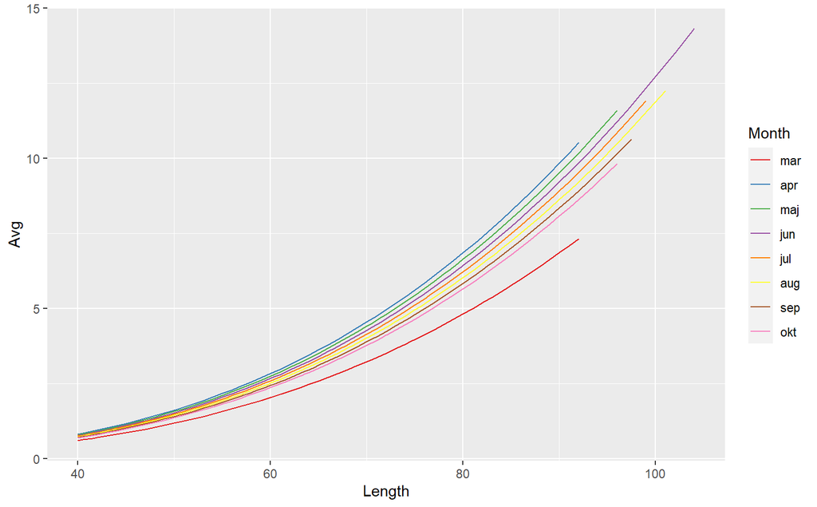

```
#> Analysis of Variance Table
#>
#> Model 1: log(Weight) ~ MonthM2 * log(Length)
#> Model 2: log(Weight) ~ MonthM4 * log(Length)
#>   Res.Df    RSS  Df Sum of Sq      F    Pr(>F)
#> 1  15653 186.94
#> 2  15665 205.19 -12   -18.241 127.28 < 2.2e-16 ***
#> ---
#> Signif. codes:  0 '***' 0.001 '**' 0.01 '*' 0.05 '.' 0.1 ' ' 1
```

## Reducing Months

Since the trout may arrive to the river in different months, we may try to group some of the months. We test different models both with month as numeric and factor.

```r
dat <- dat %>%
  mutate(MonthM5 = case_when(
    Month == "apr" ~ 1,
    Month == "maj" ~ 1,
    Month == "jun" ~ 1,
    Month == "jul" ~ 1,
    Month == "aug" ~ 1,
    Month == "sep" ~ 2,
    Month == "okt" ~ 2,
    Month == "mar" ~ 3,
  )) %>%
  mutate(MonthM6 = case_when(
    Month == "apr" ~ 1,
    Month == "maj" ~ 1,
    Month == "jun" ~ 1,
    Month == "jul" ~ 1,
    Month == "aug" ~ 1,
    Month == "sep" ~ 2,
    Month == "okt" ~ 2,
    Month == "mar" ~ 4,
  )) %>%
  mutate(MonthM7 = case_when(
    Month == "apr" ~ 1,
    Month == "maj" ~ 1,
    Month == "jun" ~ 1,
    Month == "jul" ~ 1,
    Month == "aug" ~ 1,
    Month == "sep" ~ 2,
    Month == "okt" ~ 2,
    Month == "mar" ~ 5,
  )) %>%
  mutate(MonthM8 = case_when(
    Month == "apr" ~ "P1",
    Month == "maj" ~ "P1",
    Month == "jun" ~ "P1",
    Month == "jul" ~ "P1",
    Month == "aug" ~ "P1",
    Month == "sep" ~ "P2",
    Month == "okt" ~ "P2",
    Month == "mar" ~ "P3",
  )) %>%
  mutate(MonthM9 = case_when(
    Month == "apr" ~ "P1",
    Month == "maj" ~ "P1",
    Month == "jun" ~ "P1",
    Month == "jul" ~ "P1",
    Month == "aug" ~ "P2",
    Month == "sep" ~ "P2",
    Month == "okt" ~ "P2",
    Month == "mar" ~ "P3",
  )) %>%
  mutate(MonthM10 = case_when(
    Month == "apr" ~ "P1",
    Month == "maj" ~ "P1",
    Month == "jun" ~ "P1",
    Month == "jul" ~ "P2",
    Month == "aug" ~ "P2",
    Month == "sep" ~ "P3",
    Month == "okt" ~ "P3",
    Month == "mar" ~ "P4",
  ))

testM <- function(mA, mB) {
  mAN <- paste0("MonthM",mA)
  mBN <- paste0("MonthM",mB)
  modA <- eval(substitute(lm(log(Weight) ~ variable*log(Length), dat), list(variable = as.name(mAN))))
  modB <- eval(substitute(lm(log(Weight) ~ variable*log(Length), dat), list(variable = as.name(mBN))))
  # print(summary(modA))
  # print(summary(modB))
  print(anova(modA, modB))

  datP <- expand_grid(Length = 40:max(dat$Length), unique(dat[[mAN]]))
  colnames(datP) = c("Length", mAN)
  resA <- predict(modA, datP, interval='prediction', level=0.95)
  resA <- exp(resA)
  resA <- resA %>% as_tibble() %>% mutate(Model = paste0("M",mA), ModelP = paste0("M",mA,"-",pull(datP[,2])))
  resA <- bind_cols(datP, resA) %>% select(- !! mAN)
  colnames(resA)[(ncol(resA)-4):(ncol(resA)-2)] <- c("Avg", "Lower", "Upper")

  datP <- expand_grid(Length = 40:max(dat$Length), unique(dat[[mBN]]))
  colnames(datP) = c("Length", mBN)
  resB <- predict(modB, datP, interval='prediction', level=0.95)
  resB <- exp(resB)
  resB <- resB %>% as_tibble() %>% mutate(Model = paste0("M",mB), ModelP = paste0("M",mB,"-",pull(datP[,2])))
  resB <- bind_cols(datP, resB) %>% select(- !! mBN)
  colnames(resB)[(ncol(resB)-4):(ncol(resB)-2)] <- c("Avg", "Lower", "Upper")

  res <- bind_rows(resA, resB)
  ggplot(res, aes(x = Length, y = Avg)) +
    geom_line(aes(group = ModelP, color = ModelP, linetype = Model))
}
```

We test the models against each other:

```r
for (i in 3:9) testM(i,i+1)
```

```
#> Analysis of Variance Table
#>
#> Model 1: log(Weight) ~ MonthM3 * log(Length)
#> Model 2: log(Weight) ~ MonthM4 * log(Length)
#>   Res.Df    RSS  Df Sum of Sq      F    Pr(>F)
#> 1  15653 186.94
#> 2  15665 205.19 -12   -18.241 127.28 < 2.2e-16 ***
#> ---
#> Signif. codes:  0 '***' 0.001 '**' 0.01 '*' 0.05 '.' 0.1 ' ' 1
#> Analysis of Variance Table
#>
#> Model 1: log(Weight) ~ MonthM4 * log(Length)
#> Model 2: log(Weight) ~ MonthM5 * log(Length)
#>   Res.Df    RSS Df Sum of Sq F Pr(>F)
#> 1  15665 205.19
#> 2  15665 209.96  0   -4.7746
#> Analysis of Variance Table
#>
#> Model 1: log(Weight) ~ MonthM5 * log(Length)
#> Model 2: log(Weight) ~ MonthM6 * log(Length)
#>   Res.Df    RSS Df Sum of Sq F Pr(>F)
#> 1  15665 209.96
#> 2  15665 199.35  0    10.611
#> Analysis of Variance Table
#>
#> Model 1: log(Weight) ~ MonthM6 * log(Length)
#> Model 2: log(Weight) ~ MonthM7 * log(Length)
#>   Res.Df    RSS Df Sum of Sq F Pr(>F)
#> 1  15665 199.35
#> 2  15665 196.15  0    3.1992
#> Analysis of Variance Table
#>
#> Model 1: log(Weight) ~ MonthM7 * log(Length)
#> Model 2: log(Weight) ~ MonthM8 * log(Length)
#>   Res.Df    RSS Df Sum of Sq      F    Pr(>F)
#> 1  15665 196.15
#> 2  15663 195.65  2   0.49806 19.936 2.253e-09 ***
#> ---
#> Signif. codes:  0 '***' 0.001 '**' 0.01 '*' 0.05 '.' 0.1 ' ' 1
#> Analysis of Variance Table
#>
#> Model 1: log(Weight) ~ MonthM8 * log(Length)
#> Model 2: log(Weight) ~ MonthM9 * log(Length)
#>   Res.Df    RSS Df Sum of Sq F Pr(>F)
#> 1  15663 195.65
#> 2  15663 197.97  0   -2.3135
#> Analysis of Variance Table
#>
#> Model 1: log(Weight) ~ MonthM9 * log(Length)
#> Model 2: log(Weight) ~ MonthM10 * log(Length)
#>   Res.Df    RSS Df Sum of Sq     F    Pr(>F)
#> 1  15663 197.97
#> 2  15661 195.46  2    2.5061 100.4 < 2.2e-16 ***
#> ---
#> Signif. codes:  0 '***' 0.001 '**' 0.01 '*' 0.05 '.' 0.1 ' ' 1
```

Model 10 seems to be best.

```
#> Analysis of Variance Table
#>
#> Model 1: log(Weight) ~ MonthM3 * log(Length)
#> Model 2: log(Weight) ~ MonthM8 * log(Length)
#>   Res.Df    RSS  Df Sum of Sq      F    Pr(>F)
#> 1  15653 186.94
#> 2  15663 195.65 -10   -8.7073 72.907 < 2.2e-16 ***
#> ---
#> Signif. codes:  0 '***' 0.001 '**' 0.01 '*' 0.05 '.' 0.1 ' ' 1
```

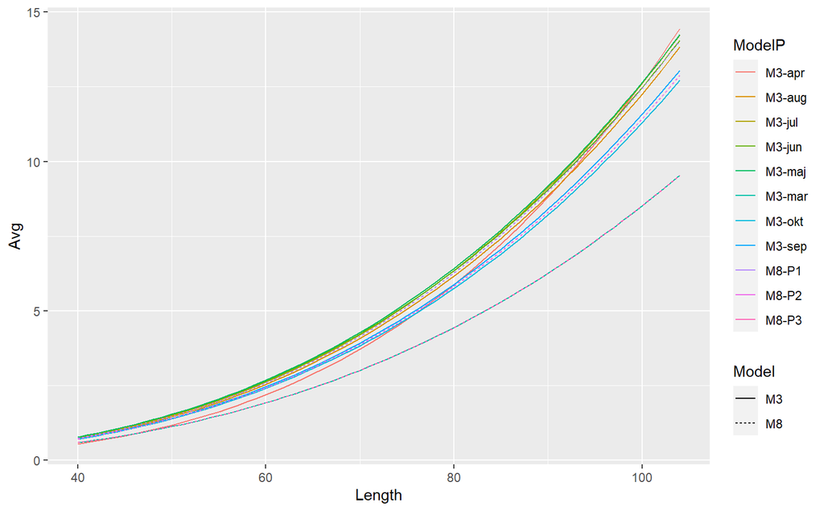

```
#> Analysis of Variance Table
#>
#> Model 1: log(Weight) ~ MonthM8 * log(Length)
#> Model 2: log(Weight) ~ MonthM10 * log(Length)
#>   Res.Df    RSS Df Sum of Sq      F    Pr(>F)
#> 1  15663 195.65
#> 2  15661 195.46  2   0.19261 7.7164 0.0004471 ***
#> ---
#> Signif. codes:  0 '***' 0.001 '**' 0.01 '*' 0.05 '.' 0.1 ' ' 1
```

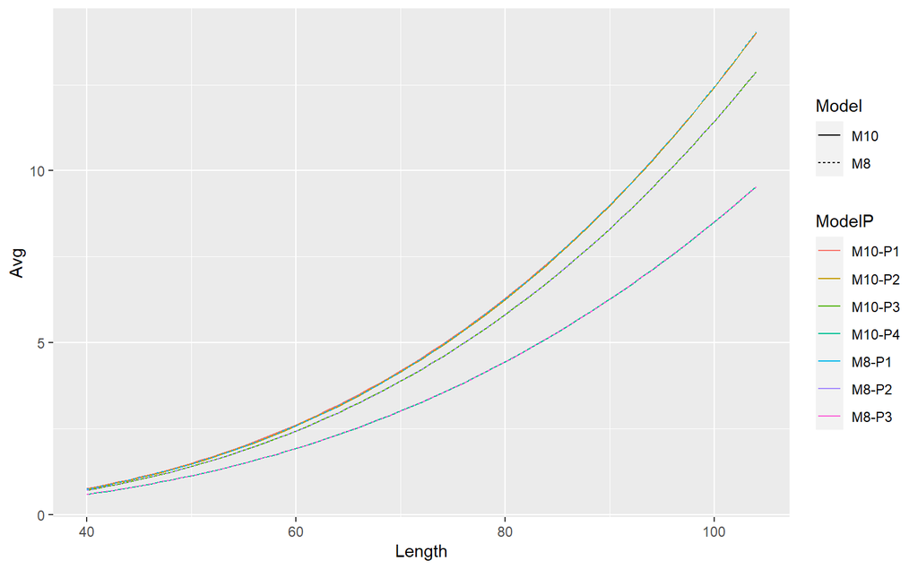

Note the only difference are which group August is added to a middle period. In August the are both new and old fish in the river.

## Arrival over years

Have the arrival of the trout changed over years? We use mean weight as a indicator.

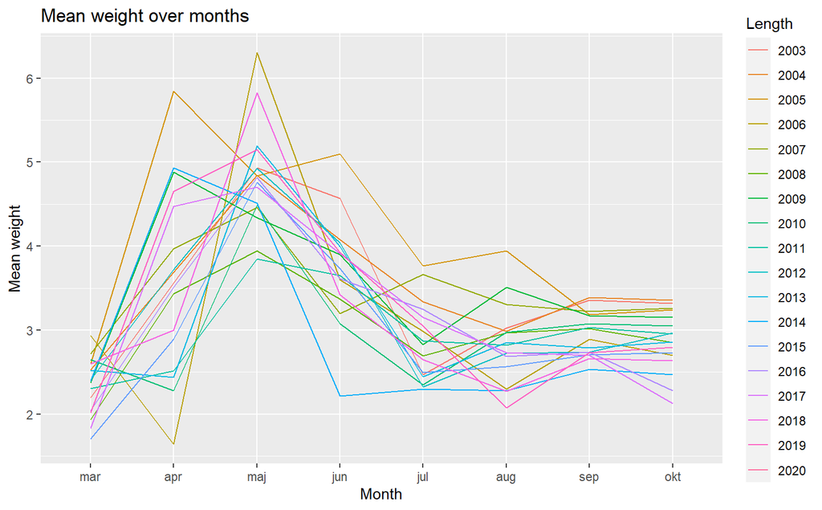

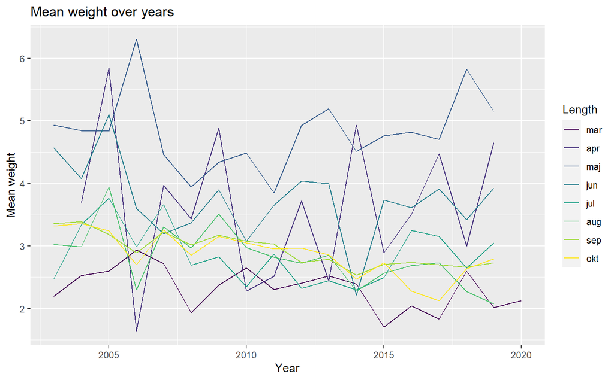

Based on the plots there don’t seem to be a relation.